# Project 4

```python
# importing the required libraries.

import numpy             as np
import pandas            as pd
import matplotlib.pyplot as plt
import seaborn           as sns

from sklearn.preprocessing   import MinMaxScaler, StandardScaler
from sklearn.model_selection import train_test_split
from sklearn.linear_model    import LogisticRegression
from sklearn.ensemble        import RandomForestClassifier, GradientBoostingClassifier
from sklearn.svm             import SVC
from sklearn.tree            import DecisionTreeClassifier
from sklearn.neighbors       import KNeighborsClassifier
from sklearn.metrics         import accuracy_score, precision_score, recall_score, f1_score, classification_report
from sklearn.model_selection import GridSearchCV

import warnings
warnings.filterwarnings('ignore')
```

```python
data = pd.read_csv('data\data.csv')

data.head()
```

|  | id | diagnosis | radius_mean | texture_mean | perimeter_mean | area_mean | smoothness_mean | compactness_mean | concavity_mean | concave_points_mean | ... | radius_worst | texture_worst | perimeter_worst | area_worst | smoothness_worst | compactness_worst | concavity_worst | concave_points_worst | symmetry_worst | fractal_dimension_worst |
| --- | --- | --- | --- | --- | --- | --- | --- | --- | --- | --- | --- | --- | --- | --- | --- | --- | --- | --- | --- | --- | --- |
| 0 | 842302 | M | 17.99 | 10.38 | 122.80 | 1001.0 | 0.11840 | 0.27760 | 0.3001 | 0.14710 | ... | 25.38 | 17.33 | 184.60 | 2019.0 | 0.1622 | 0.6656 | 0.7119 | 0.2654 | 0.4601 | 0.11890 |
| 1 | 842517 | M | 20.57 | 17.77 | 132.90 | 1326.0 | 0.08474 | 0.07864 | 0.0869 | 0.07017 | ... | 24.99 | 23.41 | 158.80 | 1956.0 | 0.1238 | 0.1866 | 0.2416 | 0.1860 | 0.2750 | 0.08902 |
| 2 | 84300903 | M | 19.69 | 21.25 | 130.00 | 1203.0 | 0.10960 | 0.15990 | 0.1974 | 0.12790 | ... | 23.57 | 25.53 | 152.50 | 1709.0 | 0.1444 | 0.4245 | 0.4504 | 0.2430 | 0.3613 | 0.08758 |
| 3 | 84348301 | M | 11.42 | 20.38 | 77.58 | 386.1 | 0.14250 | 0.28390 | 0.2414 | 0.10520 | ... | 14.91 | 26.50 | 98.87 | 567.7 | 0.2098 | 0.8663 | 0.6869 | 0.2575 | 0.6638 | 0.17300 |
| 4 | 84358402 | M | 20.29 | 14.34 | 135.10 | 1297.0 | 0.10030 | 0.13280 | 0.1980 | 0.10430 | ... | 22.54 | 16.67 | 152.20 | 1575.0 | 0.1374 | 0.2050 | 0.4000 | 0.1625 | 0.2364 | 0.07678 |

5 rows × 32 columns

```python
data.shape
```

```
(569, 32)
```

```python
data.isnull().sum()
```

```
id                         0
diagnosis                  0
radius_mean                0
texture_mean               0
perimeter_mean             0
area_mean                  0
smoothness_mean            0
compactness_mean           0
concavity_mean             0
concave_points_mean        0
symmetry_mean              0
fractal_dimension_mean     0
radius_se                  0
texture_se                 0
perimeter_se               0
area_se                    0
smoothness_se              0
compactness_se             0
concavity_se               0
concave_points_se          0
symmetry_se                0
fractal_dimension_se       0
radius_worst               0
texture_worst              0
perimeter_worst            0
area_worst                 0
smoothness_worst           0
compactness_worst          0
concavity_worst            0
concave_points_worst       0
symmetry_worst             0
fractal_dimension_worst    0
dtype: int64
```

#### In this code:

```python
data.info()
```

```
<class 'pandas.core.frame.DataFrame'>
RangeIndex: 569 entries, 0 to 568
Data columns (total 32 columns):
 #   Column                   Non-Null Count  Dtype
---  ------                   --------------  -----
 0   id                       569 non-null    int64
 1   diagnosis                569 non-null    object
 2   radius_mean              569 non-null    float64
 3   texture_mean             569 non-null    float64
 4   perimeter_mean           569 non-null    float64
 5   area_mean                569 non-null    float64
 6   smoothness_mean          569 non-null    float64
 7   compactness_mean         569 non-null    float64
 8   concavity_mean           569 non-null    float64
 9   concave_points_mean      569 non-null    float64
```

[output cut: 24 more lines]

#### In this code:

- `data.info()` is used to obtain a concise summary of the DataFrame's information. It provides details about the DataFrame's structure, including:
  - The number of non-null entries in each column (non-missing values).
  - The data type of each column (e.g., integer, float, object).
  - The total memory usage by the DataFrame.

This summary is useful for quickly understanding the dataset's size, data types, and the presence of missing values.

```python
# Count the occurrences of unique values in the 'diagnosis' column
data.diagnosis.value_counts()
```

```
B    357
M    212
Name: diagnosis, dtype: int64
```

```python
data.describe().T
```

|  | count | mean | std | min | 25% | 50% | 75% | max |
| --- | --- | --- | --- | --- | --- | --- | --- | --- |
| id | 569.0 | 3.037183e+07 | 1.250206e+08 | 8670.000000 | 869218.000000 | 906024.000000 | 8.813129e+06 | 9.113205e+08 |
| radius_mean | 569.0 | 1.412729e+01 | 3.524049e+00 | 6.981000 | 11.700000 | 13.370000 | 1.578000e+01 | 2.811000e+01 |
| texture_mean | 569.0 | 1.928965e+01 | 4.301036e+00 | 9.710000 | 16.170000 | 18.840000 | 2.180000e+01 | 3.928000e+01 |
| perimeter_mean | 569.0 | 9.196903e+01 | 2.429898e+01 | 43.790000 | 75.170000 | 86.240000 | 1.041000e+02 | 1.885000e+02 |
| area_mean | 569.0 | 6.548891e+02 | 3.519141e+02 | 143.500000 | 420.300000 | 551.100000 | 7.827000e+02 | 2.501000e+03 |
| smoothness_mean | 569.0 | 9.636028e-02 | 1.406413e-02 | 0.052630 | 0.086370 | 0.095870 | 1.053000e-01 | 1.634000e-01 |
| compactness_mean | 569.0 | 1.043410e-01 | 5.281276e-02 | 0.019380 | 0.064920 | 0.092630 | 1.304000e-01 | 3.454000e-01 |
| concavity_mean | 569.0 | 8.879932e-02 | 7.971981e-02 | 0.000000 | 0.029560 | 0.061540 | 1.307000e-01 | 4.268000e-01 |
| concave_points_mean | 569.0 | 4.891915e-02 | 3.880284e-02 | 0.000000 | 0.020310 | 0.033500 | 7.400000e-02 | 2.012000e-01 |
| symmetry_mean | 569.0 | 1.811619e-01 | 2.741428e-02 | 0.106000 | 0.161900 | 0.179200 | 1.957000e-01 | 3.040000e-01 |
| fractal_dimension_mean | 569.0 | 6.279761e-02 | 7.060363e-03 | 0.049960 | 0.057700 | 0.061540 | 6.612000e-02 | 9.744000e-02 |
| radius_se | 569.0 | 4.051721e-01 | 2.773127e-01 | 0.111500 | 0.232400 | 0.324200 | 4.789000e-01 | 2.873000e+00 |
| texture_se | 569.0 | 1.216853e+00 | 5.516484e-01 | 0.360200 | 0.833900 | 1.108000 | 1.474000e+00 | 4.885000e+00 |
| perimeter_se | 569.0 | 2.866059e+00 | 2.021855e+00 | 0.757000 | 1.606000 | 2.287000 | 3.357000e+00 | 2.198000e+01 |
| area_se | 569.0 | 4.033708e+01 | 4.549101e+01 | 6.802000 | 17.850000 | 24.530000 | 4.519000e+01 | 5.422000e+02 |
| smoothness_se | 569.0 | 7.040979e-03 | 3.002518e-03 | 0.001713 | 0.005169 | 0.006380 | 8.146000e-03 | 3.113000e-02 |
| compactness_se | 569.0 | 2.547814e-02 | 1.790818e-02 | 0.002252 | 0.013080 | 0.020450 | 3.245000e-02 | 1.354000e-01 |
| concavity_se | 569.0 | 3.189372e-02 | 3.018606e-02 | 0.000000 | 0.015090 | 0.025890 | 4.205000e-02 | 3.960000e-01 |
| concave_points_se | 569.0 | 1.179614e-02 | 6.170285e-03 | 0.000000 | 0.007638 | 0.010930 | 1.471000e-02 | 5.279000e-02 |
| symmetry_se | 569.0 | 2.054230e-02 | 8.266372e-03 | 0.007882 | 0.015160 | 0.018730 | 2.348000e-02 | 7.895000e-02 |
| fractal_dimension_se | 569.0 | 3.794904e-03 | 2.646071e-03 | 0.000895 | 0.002248 | 0.003187 | 4.558000e-03 | 2.984000e-02 |
| radius_worst | 569.0 | 1.626919e+01 | 4.833242e+00 | 7.930000 | 13.010000 | 14.970000 | 1.879000e+01 | 3.604000e+01 |
| texture_worst | 569.0 | 2.567722e+01 | 6.146258e+00 | 12.020000 | 21.080000 | 25.410000 | 2.972000e+01 | 4.954000e+01 |
| perimeter_worst | 569.0 | 1.072612e+02 | 3.360254e+01 | 50.410000 | 84.110000 | 97.660000 | 1.254000e+02 | 2.512000e+02 |
| area_worst | 569.0 | 8.805831e+02 | 5.693570e+02 | 185.200000 | 515.300000 | 686.500000 | 1.084000e+03 | 4.254000e+03 |
| smoothness_worst | 569.0 | 1.323686e-01 | 2.283243e-02 | 0.071170 | 0.116600 | 0.131300 | 1.460000e-01 | 2.226000e-01 |
| compactness_worst | 569.0 | 2.542650e-01 | 1.573365e-01 | 0.027290 | 0.147200 | 0.211900 | 3.391000e-01 | 1.058000e+00 |
| concavity_worst | 569.0 | 2.721885e-01 | 2.086243e-01 | 0.000000 | 0.114500 | 0.226700 | 3.829000e-01 | 1.252000e+00 |
| concave_points_worst | 569.0 | 1.146062e-01 | 6.573234e-02 | 0.000000 | 0.064930 | 0.099930 | 1.614000e-01 | 2.910000e-01 |
| symmetry_worst | 569.0 | 2.900756e-01 | 6.186747e-02 | 0.156500 | 0.250400 | 0.282200 | 3.179000e-01 | 6.638000e-01 |
| fractal_dimension_worst | 569.0 | 8.394582e-02 | 1.806127e-02 | 0.055040 | 0.071460 | 0.080040 | 9.208000e-02 | 2.075000e-01 |

#### In this code:

- `data.describe()` computes summary statistics for all numerical columns in the DataFrame, including `count`, `mean`, `standard deviation`, `minimum`, and various quartiles (`25%`, `50%`, and `75%`).
- `.T` is used to transpose the resulting summary statistics DataFrame, which swaps rows and columns. Transposing the summary statistics makes it easier to read, as it aligns the statistics by column name.

This code quickly overview of the central tendencies and variability of numerical data in a DataFrame, aiding in the initial data exploration and understanding of the dataset's distribution.

```python
# Summary statistics for the object columns

data.describe(include='object')
```

|  | diagnosis |
| --- | --- |
| count | 569 |
| unique | 2 |
| top | B |
| freq | 357 |

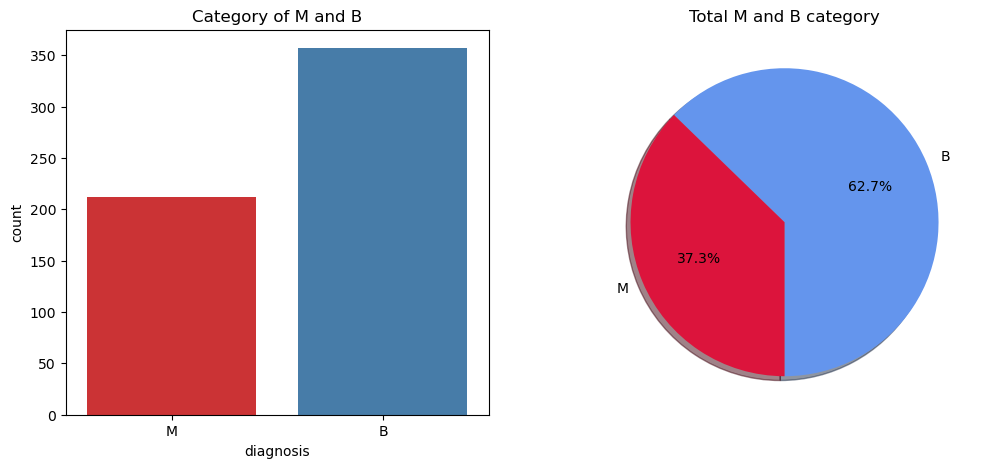

```python
plt.figure(figsize=(12,5))

plt.subplot(1,2,1)
sns.countplot(x='diagnosis',data=data, palette='Set1')
plt.title("Category of M and B")
plt.subplot(1,2,2)
labels =data['diagnosis'].value_counts(sort = True).index
sizes = data['diagnosis'].value_counts(sort = True)

plt.pie(sizes,labels=labels,autopct='%1.1f%%', shadow=True, startangle=270, colors=['cornflowerblue', 'crimson'])
plt.title('Total M and B category',size = 12)

plt.show()
```

#### In this code:

- A figure with a size of (12, 5) is created to hold two subplots side by side.
- Subplot 1 (left side): A countplot is generated using Seaborn's `sns.countplot()` to visualize the distribution of 'diagnosis' categories ('M' and 'B').
- Subplot 2 (right side): A pie chart is created using Matplotlib to show the percentage distribution of 'diagnosis' categories. The labels, sizes, and colors for the pie chart are defined based on the counts of `'M'` and `'B'` categories.
- Finally, both subplots are displayed using `plt.show()`.

This code provides a visual representation of the distribution of `'M'` and `'B'` categories in the 'diagnosis' column, making it easier to understand the categorical data in the dataset.

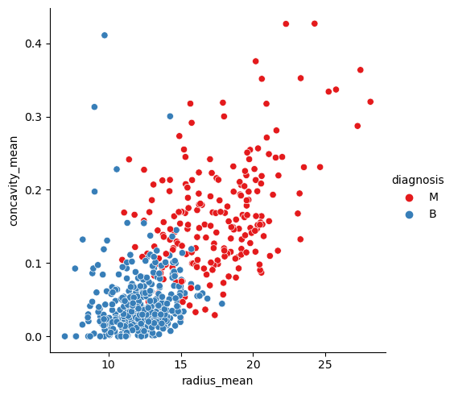

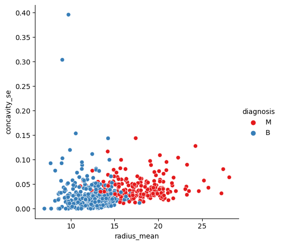

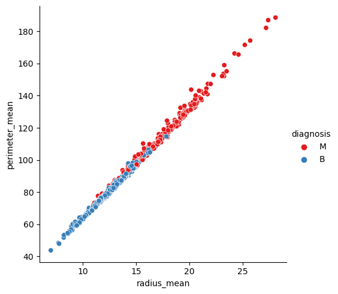

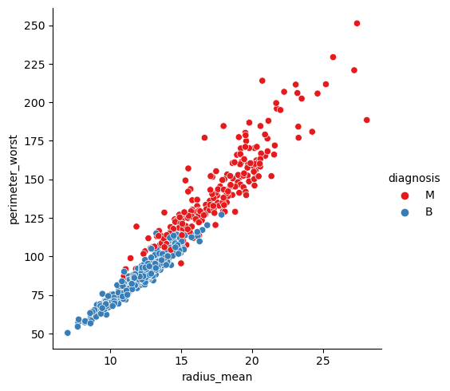

```python
for i in ['concavity_mean', 'concavity_se', 'perimeter_mean', 'perimeter_worst']:
    sns.relplot(data.radius_mean, i, hue= data.diagnosis, data = data, palette = 'Set1')
    plt.show()
```

#### In this code:

The provided code snippet uses Seaborn to create a series of relational plots (relplots) to visualize the relationships between the 'radius_mean' column and four other specified columns (`'concavity_mean'`, `'concavity_se'`, `'perimeter_mean'`, `'perimeter_worst'`) in the Pandas DataFrame `data`. Each relplot displays the relationship with a different column and uses the `'diagnosis'` column as the hue (coloring) to differentiate between categories.

This code allows you to explore the relationships between 'radius_mean' and the specified columns while considering the diagnosis categories as a visual differentiator. It can provide insights into how these variables relate to each other in the dataset.

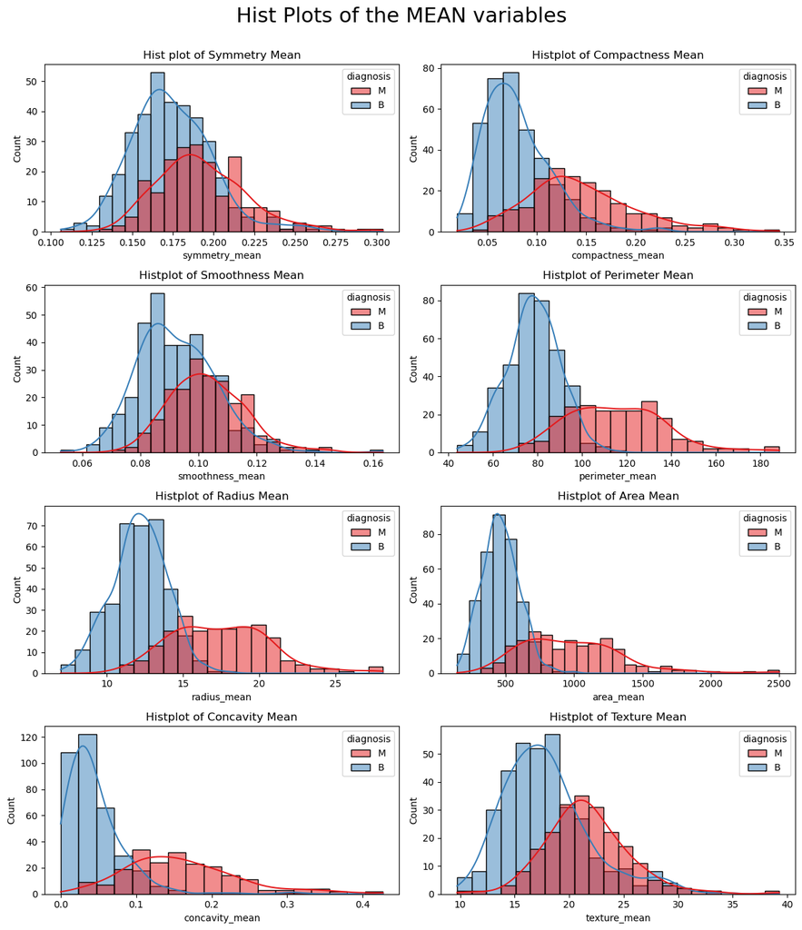

```python
# Create a figure with a grid of histogram plots
fig = plt.figure(figsize=(12, 14))
plt.suptitle("Hist Plots of the MEAN variables\n", fontsize=22)

# Subplot #1: Histogram plot of 'Symmetry Mean'
plt.subplot(421)
plt.title('Hist plot of Symmetry Mean')
sns.histplot(data=data, x=data.symmetry_mean, kde=True, hue='diagnosis', palette='Set1')

# Subplot #2: Histogram plot of 'Compactness Mean'
plt.subplot(422)
plt.title('Histplot of Compactness Mean')
sns.histplot(data=data, x=data.compactness_mean, kde=True, hue='diagnosis', palette='Set1')

# Subplot #3: Histogram plot of 'Smoothness Mean'
plt.subplot(423)
plt.title('Histplot of Smoothness Mean')
sns.histplot(data=data, x=data.smoothness_mean, kde=True, hue='diagnosis', palette='Set1')

# Subplot #4: Histogram plot of 'Perimeter Mean'
plt.subplot(424)
plt.title('Histplot of Perimeter Mean')
sns.histplot(data=data, x=data.perimeter_mean, kde=True, hue='diagnosis', palette='Set1')

# Subplot #5: Histogram plot of 'Radius Mean'
plt.subplot(425)
plt.title('Histplot of Radius Mean')
sns.histplot(data=data, x=data.radius_mean, kde=True, hue='diagnosis', palette='Set1')

# Subplot #6: Histogram plot of 'Area Mean'
plt.subplot(426)
plt.title('Histplot of Area Mean')
sns.histplot(data=data, x=data.area_mean, kde=True, hue='diagnosis', palette='Set1')

# Subplot #7: Histogram plot of 'Concavity Mean'
plt.subplot(427)
plt.title('Histplot of Concavity Mean')
sns.histplot(data=data, x=data.concavity_mean, kde=True, hue='diagnosis', palette='Set1')

# Subplot #8: Histogram plot of 'Texture Mean'
plt.subplot(428)
plt.title('Histplot of Texture Mean')
sns.histplot(data=data, x=data.texture_mean, kde=True, hue='diagnosis', palette='Set1')

# Adjust layout and display the plots
plt.tight_layout()
plt.show()
```

### In this code:

The above code creates a grid of histogram plots for several mean-related variables in the data. Each subplot represents the distribution of a specific variable, and the histograms are colored by the 'diagnosis' category (`'M'` and `'B'`). This code provides a clear visualization of the distribution of these mean-related variables for both `'M'` and `'B'` diagnosis categories, allowing for a quick comparison of their distributions.

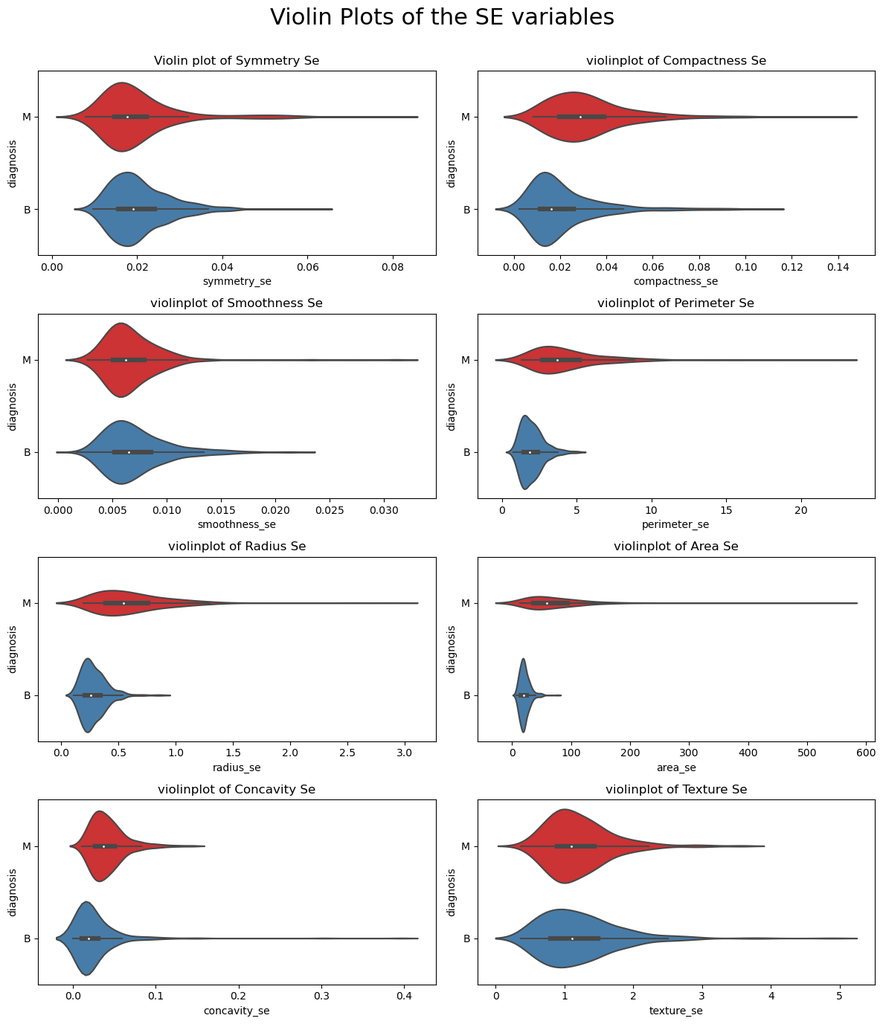

```python
fig = plt.figure(figsize = (12, 14))
plt.suptitle("Violin Plots of the SE variables\n", fontsize = 22)

#  subplot #1
plt.subplot(421)
plt.title('Violin plot of Symmetry Se')
sns.violinplot(x=data.symmetry_se, y=data.diagnosis, data=data, palette='Set1')

#  subplot #2
plt.subplot(422)
plt.title('violinplot of Compactness Se')
sns.violinplot(x=data.compactness_se, y=data.diagnosis, data=data, palette='Set1')

#  subplot #3
plt.subplot(423)
plt.title('violinplot of Smoothness Se')
sns.violinplot(x=data.smoothness_se, y=data.diagnosis, data=data, palette='Set1')

#  subplot #4
plt.subplot(424)
plt.title('violinplot of Perimeter Se')
sns.violinplot(x=data.perimeter_se, y=data.diagnosis, data=data, palette='Set1')

#  subplot #5
plt.subplot(425)
plt.title('violinplot of Radius Se')
sns.violinplot(x=data.radius_se, y=data.diagnosis, data=data, palette='Set1')

#  subplot #6
plt.subplot(426)
plt.title('violinplot of Area Se')
sns.violinplot(x=data.area_se, y=data.diagnosis, data=data, palette='Set1')

#  subplot #7
plt.subplot(427)
plt.title('violinplot of Concavity Se')
sns.violinplot(x=data.concavity_se, y=data.diagnosis, data=data, palette='Set1')

#  subplot #8
plt.subplot(428)
plt.title('violinplot of Texture Se')
sns.violinplot(x=data.texture_se, y=data.diagnosis, data=data, palette='Set1')

plt.tight_layout()
plt.show()
```

#### In this code:

The above line of code creates a grid of violin plots for several variables with `"SE"` statistics in the data. Each subplot represents the distribution of a specific variable, and the violin plots are grouped by the `'diagnosis'` category (`'M'` and `'B'`).

This code provides a clear visualization of the distribution of these `"SE"` variables for both `'M'` and `'B'` diagnosis categories, allowing for a quick comparison of their distributions.

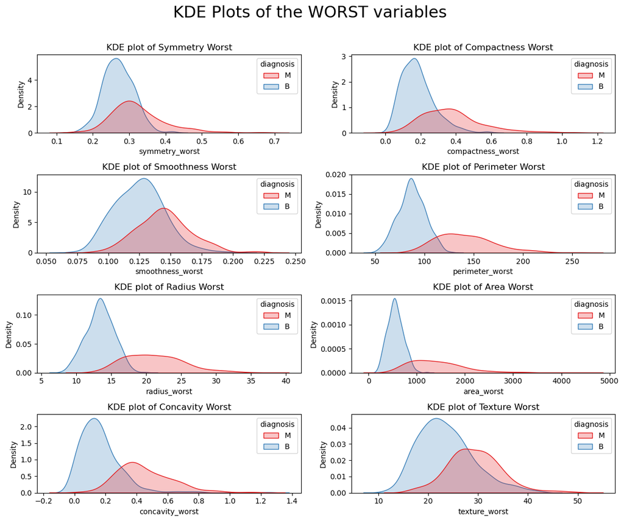

```python
fig = plt.figure(figsize = (12, 10))
plt.suptitle("KDE Plots of the WORST variables\n", fontsize = 22)

#  subplot #1
plt.subplot(421)
plt.title('KDE plot of Symmetry Worst')
sns.kdeplot(data.symmetry_worst, hue=data.diagnosis, palette='Set1', shade='fill')

#  subplot #2
plt.subplot(422)
plt.title('KDE plot of Compactness Worst')
sns.kdeplot(data.compactness_worst, hue=data.diagnosis, palette='Set1', shade='fill')

#  subplot #3
plt.subplot(423)
plt.title('KDE plot of Smoothness Worst')
sns.kdeplot(data.smoothness_worst, hue=data.diagnosis, palette='Set1', shade='fill')

#  subplot #4
plt.subplot(424)
plt.title('KDE plot of Perimeter Worst')
sns.kdeplot(data.perimeter_worst, hue=data.diagnosis, palette='Set1', shade='fill')

#  subplot #5
plt.subplot(425)
plt.title('KDE plot of Radius Worst')
sns.kdeplot(data.radius_worst, hue=data.diagnosis, palette='Set1', shade='fill')

#  subplot #6
plt.subplot(426)
plt.title('KDE plot of Area Worst')
sns.kdeplot(data.area_worst, hue=data.diagnosis, palette='Set1', shade='fill')

#  subplot #7
plt.subplot(427)
plt.title('KDE plot of Concavity Worst')
sns.kdeplot(data.concavity_worst, hue=data.diagnosis, palette='Set1', shade='fill')

#  subplot #8
plt.subplot(428)
plt.title('KDE plot of Texture Worst')
sns.kdeplot(data.texture_worst, hue=data.diagnosis, palette='Set1', shade='fill')

plt.tight_layout()
plt.show()
```

#### In this code:

The provided code creates a grid of Kernel Density Estimation (KDE) plots for several variables with `"Worst"` statistics in the data. Each subplot represents the KDE plot of a specific variable, and the plots are colored by the 'diagnosis' category (`'M'` and `'B'`).

This code provides a clear visualization of the KDE plots for these `"Worst"` variables, showing how the distributions vary between `'M'` and `'B'` diagnosis categories.

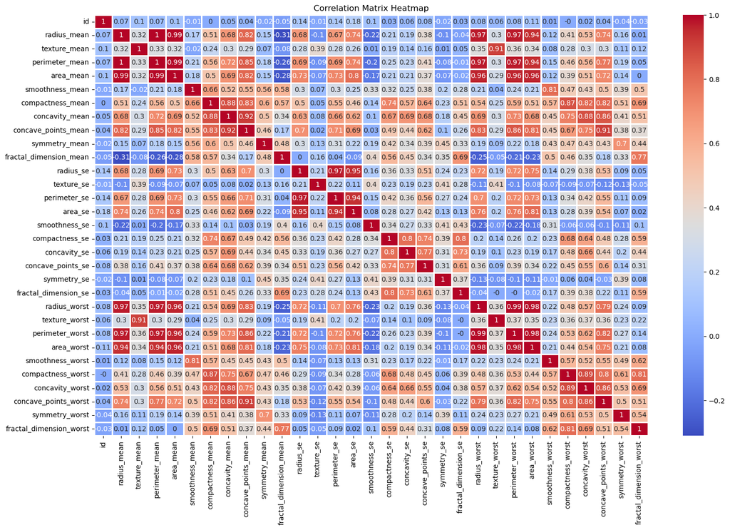

```python
# Correlation matrix heatmap

correlation_matrix = round(data.corr(), 2)
plt.figure(figsize = (18, 11))
sns.heatmap(correlation_matrix, annot = True, cmap = "coolwarm", linewidths=0.99, fmt='.2g', square=False)
plt.title('Correlation Matrix Heatmap')

plt.show()
```

This code provides a visual representation of the correlation between numerical variables in the dataset, which can help identify relationships and patterns among the variables.

```python
# reseting index for the data
data = data.reset_index(drop=True)
```

```python
# initializing MinMaxScaler and StandardScaler

min_max_scaler  = MinMaxScaler()
standard_scaler = StandardScaler()
```

The above code initializes two scalers, `MinMaxScaler` and `StandardScaler`, which are commonly used for preprocessing and scaling numerical data.

```python
# converting the categorical values of "diagnosis" column from B and M to 0 and 1 respectively.

mapping = {'B': 0, 'M': 1}

data.diagnosis = data.diagnosis.map(mapping)
```

The above code converts the categorical values in the `diagnosis` column from `B` and `M` to numerical values, specifically `0` and `1`, respectively. This type of encoding is often performed when you want to use categorical data in machine learning algorithms that require numerical input.

After running this code, the `diagnosis` column in the DataFrame will contain `0` for `Benign` cases and `1` for `Malignant` cases, which can be used as target labels for classification tasks.

```python
# storing the target column (diagnosis)
y = data.diagnosis

# storing the predictors
x = data.drop(columns=['id', 'diagnosis'], axis=1)
```

The provided code prepares the target column and predictor variables for a machine learning task. Once these variables are defined, you can use them to train and evaluate machine learning models. `x` will contain the input features, and `y` will contain the corresponding target labels.

```python
# Splitting the dataset into training and testing sets
# xtrain: Features for training data
# xtest: Features for testing data
# ytrain: Target labels for training data
# ytest: Target labels for testing data
# test_size: Specifies the proportion of data to allocate to the testing set (25% in this case)
# random_state: Sets a seed for randomization to ensure reproducibility of results

xtrain, xtest, ytrain, ytest = train_test_split(x, y, test_size = 0.25, random_state = 0)
```

```python
# Perform Min-Max scaling on the training and testing data
# min_max_xtrain: Scaled training data using Min-Max scaling
# min_max_xtest: Scaled testing data using Min-Max scaling
# min_max_scaler: Min-Max scaler object used for scaling
# xtrain: Original training data
# xtest: Original testing data

min_max_xtrain  = min_max_scaler.fit_transform(xtrain)
min_max_xtest  = min_max_scaler.fit_transform(xtest)
```

```python
# Applying StandardScaler on both the training and testing data
# standard_xtrain: Scaled training data using Standardization
# standard_xtest: Scaled testing data using Standardization

standard_xtrain = standard_scaler.fit_transform(xtrain)
standard_xtest = standard_scaler.fit_transform(xtest)
```

```python
# Count the occurrences of each unique value in the 'diagnosis' column
# Returns a Series with counts for each unique value

data.diagnosis.value_counts()
```

```
0    357
1    212
Name: diagnosis, dtype: int64
```

```python
# Define classifiers

classifiers = {
    "Logistic Regression"   : LogisticRegression(),
    "Random Forest"         : RandomForestClassifier(),
    "Support Vector Machine": SVC(),
    "Decision Tree"         : DecisionTreeClassifier(),
    "Gradient Boosting"     : GradientBoostingClassifier(),
    "K-Nearest Neighbors"   : KNeighborsClassifier()
}
```

In the above code.

- We define a Python dictionary named classifiers that stores various machine learning classifiers as key-value pairs.
- Each key represents the name of a classifier (e.g., "Logistic Regression," "Random Forest," etc.).
- The corresponding value for each key is an instance of the respective classifier class (e.g., LogisticRegression(), RandomForestClassifier(), etc.).
- This dictionary is used to store and organize different machine learning models, making it convenient for experimentation and comparison of various algorithms in a machine learning workflow.

```python
# Initialize lists to store metric scores for scaled data through MinMaxScaler.
accuracy_scores_mm  = []
precision_scores_mm = []
recall_scores_mm    = []
f1_scores_mm        = []
```

#### In this code:

- We are initializing empty lists to store metric scores (e.g., accuracy, precision, recall, F1 score) for data that has been scaled using Min-Max Scaling (`MinMaxScaler`).
- Each list is associated with a specific metric (e.g., `accuracy_scores_mm` for accuracy scores).
- These lists will be populated with metric scores during the evaluation of machine learning models trained on Min-Max scaled data. This allows for the storage and analysis of model performance results.

```python
# Train and evaluate machine learning classifiers
# Iterate through each classifier in the 'classifiers' dictionary

for name, clf in classifiers.items():

    # Display the classifier's name
    print(f"Training {name}...")

    # Train the classifier using Min-Max scaled training data
    clf.fit(min_max_xtrain, ytrain)

    # Predict the target labels using the classifier on Min-Max scaled testing data
    y_pred = clf.predict(min_max_xtest)

    # Calculate and display evaluation metrics (Accuracy, Precision, Recall, F1-Score)
    accuracy = accuracy_score(ytest, y_pred)
    precision = precision_score(ytest, y_pred)
    recall = recall_score(ytest, y_pred)
    f1 = f1_score(ytest, y_pred)

    # Append the computed metric scores to their respective lists
    accuracy_scores_mm.append(accuracy)
    precision_scores_mm.append(precision)
    recall_scores_mm.append(recall)
    f1_scores_mm.append(f1)

    # Display the computed metric scores
    print(f"Accuracy: {accuracy:.2f}")
    print(f"Precision: {precision:.2f}")
    print(f"Recall: {recall:.2f}")
    print(f"F1-Score: {f1:.2f}")

    # Generate and display a classification report
    report = classification_report(ytest, y_pred)
    print("Classification Report:\n", report)
    print("-" * 100)
```

```
Training Logistic Regression...
Accuracy: 0.94
Precision: 0.85
Recall: 1.00
F1-Score: 0.92
Classification Report:
               precision    recall  f1-score   support

           0       1.00      0.90      0.95        90
           1       0.85      1.00      0.92        53

    accuracy                           0.94       143
   macro avg       0.93      0.95      0.93       143
weighted avg       0.95      0.94      0.94       143

----------------------------------------------------------------------------------------------------
Training Random Forest...
Accuracy: 0.92
Precision: 0.82
Recall: 1.00
F1-Score: 0.90
Classification Report:
               precision    recall  f1-score   support

           0       1.00      0.87      0.93        90
           1       0.82      1.00      0.90        53

    accuracy                           0.92       143
   macro avg       0.91      0.93      0.91       143
weighted avg       0.93      0.92      0.92       143

----------------------------------------------------------------------------------------------------
Training Support Vector Machine...
Accuracy: 0.91
Precision: 0.80
Recall: 1.00
F1-Score: 0.89
Classification Report:
               precision    recall  f1-score   support

```

[output cut: 41 more lines]

```
Accuracy: 0.92
Precision: 0.83
Recall: 1.00
F1-Score: 0.91
Classification Report:
               precision    recall  f1-score   support

           0       1.00      0.88      0.93        90
           1       0.83      1.00      0.91        53

    accuracy                           0.92       143
   macro avg       0.91      0.94      0.92       143
weighted avg       0.94      0.92      0.92       143

----------------------------------------------------------------------------------------------------
```

#### In this code:

- The script iterates through each classifier defined in the classifiers dictionary.
- For each classifier:
  - It trains the classifier using Min-Max scaled training data (min_max_xtrain) and corresponding target labels (ytrain).
  - Predictions are made on the Min-Max scaled testing data (min_max_xtest), and the predicted labels are stored in y_pred.
  - Various evaluation metrics such as accuracy, precision, recall, and F1-score are calculated using the predicted labels and actual labels (ytest).
  - The computed metric scores are appended to their respective lists (e.g., accuracy_scores_mm, precision_scores_mm).
  - The script prints out the evaluation results for each classifier, including the classification report, which provides additional insights into model performance.
  - A line of dashes (-) is printed to visually separate the results for each classifier.

This code allows you to train multiple classifiers, evaluate their performance, and store the evaluation results for further analysis and visualization.

```python
# Initialize lists to store metric scores for scaled data.
accuracy_scores_st  = []
precision_scores_st = []
recall_scores_st    = []
f1_scores_st        = []
```

#### In this code:

- We are initializing empty lists to store metric scores (e.g., accuracy, precision, recall, F1 score) for data that has been scaled using Standardization (Z-score scaling).
- Each list is associated with a specific metric (e.g., accuracy_scores_st for accuracy scores).
- These lists will be populated with metric scores during the evaluation of machine learning models trained on standardized data. This allows for the storage and analysis of model performance results when using Standardization as a preprocessing step.

```python
# Train and evaluate classifiers
for name, clf in classifiers.items():

    print(f"Training {name}...")
    clf.fit(standard_xtrain, ytrain)
    y_pred = clf.predict(standard_xtest)

    accuracy = accuracy_score(ytest, y_pred)
    precision = precision_score(ytest, y_pred)
    recall = recall_score(ytest, y_pred)
    f1 = f1_score(ytest, y_pred)

    accuracy_scores_st.append(accuracy)
    precision_scores_st.append(precision)
    recall_scores_st.append(recall)
    f1_scores_st.append(f1)

    print(f"Accuracy: {accuracy:.3f}")
    print(f"Precision: {precision:.3f}")
    print(f"Recall: {recall:.3f}")
    print(f"F1-Score: {f1:.3f}")

    report = classification_report(ytest, y_pred)
    print("Classification Report:\n", report)
    print("-" * 100)
```

```
Training Logistic Regression...
Accuracy: 0.958
Precision: 0.927
Recall: 0.962
F1-Score: 0.944
Classification Report:
               precision    recall  f1-score   support

           0       0.98      0.96      0.97        90
           1       0.93      0.96      0.94        53

    accuracy                           0.96       143
   macro avg       0.95      0.96      0.96       143
weighted avg       0.96      0.96      0.96       143

----------------------------------------------------------------------------------------------------
Training Random Forest...
Accuracy: 0.965
Precision: 0.944
Recall: 0.962
F1-Score: 0.953
Classification Report:
               precision    recall  f1-score   support

           0       0.98      0.97      0.97        90
           1       0.94      0.96      0.95        53

    accuracy                           0.97       143
   macro avg       0.96      0.96      0.96       143
weighted avg       0.97      0.97      0.97       143

----------------------------------------------------------------------------------------------------
Training Support Vector Machine...
Accuracy: 0.965
Precision: 0.962
Recall: 0.943
F1-Score: 0.952
Classification Report:
               precision    recall  f1-score   support

```

[output cut: 41 more lines]

```
Accuracy: 0.951
Precision: 0.979
Recall: 0.887
F1-Score: 0.931
Classification Report:
               precision    recall  f1-score   support

           0       0.94      0.99      0.96        90
           1       0.98      0.89      0.93        53

    accuracy                           0.95       143
   macro avg       0.96      0.94      0.95       143
weighted avg       0.95      0.95      0.95       143

----------------------------------------------------------------------------------------------------
```

#### In this code:

- The script iterates through each classifier defined in the classifiers dictionary.
- For each classifier:
  - It trains the classifier using standardized training data (standard_xtrain) and corresponding target labels (ytrain).
  - Predictions are made on the standardized testing data (standard_xtest), and the predicted labels are stored in y_pred.
  - Various evaluation metrics such as accuracy, precision, recall, and F1-score are calculated using the predicted labels and actual labels (ytest).
  - The computed metric scores are appended to their respective lists (e.g., accuracy_scores_st, precision_scores_st).
  - The script prints out the evaluation results for each classifier, including the classification report, which provides additional insights into model performance.
  - A line of dashes (-) is printed to visually separate the results for each classifier.

This code allows you to train multiple classifiers, evaluate their performance on standardized data, and store the evaluation results for further analysis.

```python
lr_mm  = [accuracy_scores_mm[0], precision_scores_mm[0], recall_scores_mm[0], f1_scores_mm[0]]
rf_mm  = [accuracy_scores_mm[1], precision_scores_mm[1], recall_scores_mm[1], f1_scores_mm[1]]
svm_mm = [accuracy_scores_mm[2], precision_scores_mm[2], recall_scores_mm[2], f1_scores_mm[2]]
dt_mm  = [accuracy_scores_mm[3], precision_scores_mm[3], recall_scores_mm[3], f1_scores_mm[3]]
xgb_mm = [accuracy_scores_mm[4], precision_scores_mm[4], recall_scores_mm[4], f1_scores_mm[4]]
knn_mm = [accuracy_scores_mm[5], precision_scores_mm[5], recall_scores_mm[5], f1_scores_mm[5]]
```

#### In this code:

- Lists are created to organize metric scores (e.g., accuracy, precision, recall, F1-score) for different classifiers that have been trained and evaluated using Min-Max scaled data.
- Each list corresponds to a specific classifier:
  - `lr_mm` stores metric scores for the Logistic Regression classifier.
  - `rf_mm` stores metric scores for the Random Forest classifier.
  - `svm_mm` stores metric scores for the Support Vector Machine classifier.
  - `dt_mm` stores metric scores for the Decision Tree classifier.
  - `xgb_mm` stores metric scores for the Gradient Boosting classifier.
  - `knn_mm` stores metric scores for the K-Nearest Neighbors classifier.

These organized lists can be useful for comparing and visualizing the performance of different classifiers based on their respective metric scores when using Min-Max scaling.

```python
lr_st  = [accuracy_scores_st[0], precision_scores_st[0], recall_scores_st[0], f1_scores_st[0]]
rf_st  = [accuracy_scores_st[1], precision_scores_st[1], recall_scores_st[1], f1_scores_st[1]]
svm_st = [accuracy_scores_st[2], precision_scores_st[2], recall_scores_st[2], f1_scores_st[2]]
dt_st  = [accuracy_scores_st[3], precision_scores_st[3], recall_scores_st[3], f1_scores_st[3]]
xgb_st = [accuracy_scores_st[4], precision_scores_st[4], recall_scores_st[4], f1_scores_st[4]]
knn_st = [accuracy_scores_st[5], precision_scores_st[5], recall_scores_st[5], f1_scores_st[5]]
```

#### In this code:

- Lists are created to organize metric scores (e.g., accuracy, precision, recall, F1-score) for different classifiers that have been trained and evaluated using standardized (Standardization) data.
- Each list corresponds to a specific classifier:
  - `lr_st` stores metric scores for the Logistic Regression classifier with Standardization.
  - `rf_st` stores metric scores for the Random Forest classifier with Standardization.
  - `svm_st` stores metric scores for the Support Vector Machine classifier with Standardization.
  - `dt_st` stores metric scores for the Decision Tree classifier with Standardization.
  - `xgb_st` stores metric scores for the Gradient Boosting classifier with Standardization.
  - `knn_st` stores metric scores for the K-Nearest Neighbors classifier with Standardization.

These organized lists can be useful for comparing and visualizing the performance of different classifiers based on their respective metric scores when using Standardization as a preprocessing step.

```python
classifiers_names = ["Logistic Regression", "Random Forest", "Support Vector Machine",
                     "Decision Tree", "Gradient Boosting", "K-Nearest Neighbors"]

classifiers_names == list(classifiers.keys())
# list(classifiers.keys())
```

```
True
```

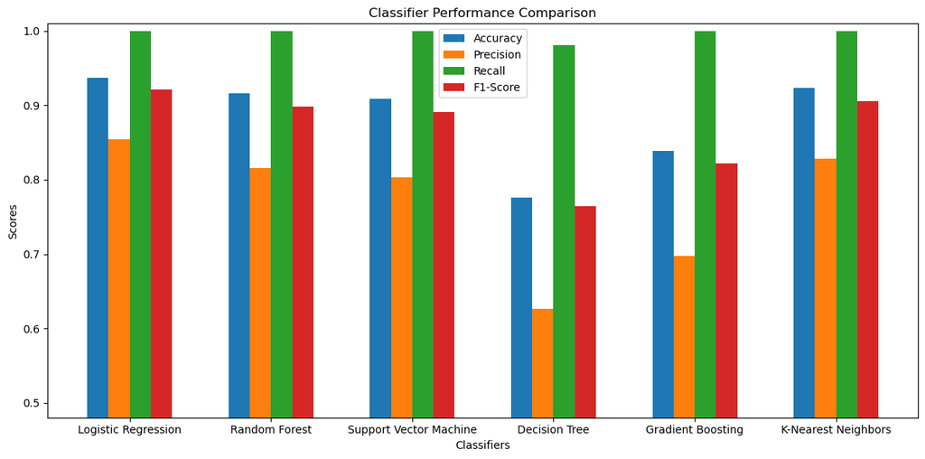

```python
classifiers_names = list(classifiers.keys())
metrics = ['Accuracy', 'Precision', 'Recall', 'F1-Score']
num_classifiers = len(classifiers_names)
num_metrics = len(metrics)
bar_width = 0.15
index = np.arange(num_classifiers)

plt.figure(figsize=(12, 6))

for i in range(num_metrics):
    metric_scores = [lr_mm[i], rf_mm[i], svm_mm[i], dt_mm[i], xgb_mm[i], knn_mm[i]]
    plt.bar(index + i * bar_width, metric_scores, bar_width, label=metrics[i])

plt.xlabel('Classifiers')
plt.ylabel('Scores')
plt.title('Classifier Performance Comparison')
plt.xticks(index + bar_width * (num_metrics - 1) / 2, classifiers_names)
plt.legend()
plt.ylim(0.48, 1.01)
plt.tight_layout()
plt.show()
```

#### In this code:

- The number of classifiers and metrics is determined.
- Classifier names are extracted from the keys of the `classifiers` dictionary, and metrics are defined.
- A grouped bar chart is created to compare performance metrics (`Accuracy`, `Precision`, `Recall`, `F1-Score`) of different classifiers using `Min-Max` scaled data.

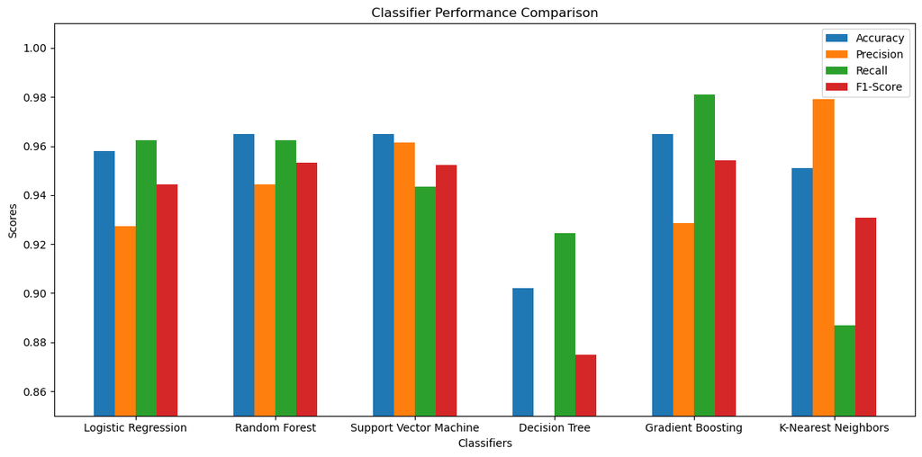

```python
plt.figure(figsize=(12, 6))

for i in range(num_metrics):
    metric_scores = [lr_st[i], rf_st[i], svm_st[i], dt_st[i], xgb_st[i], knn_st[i]]
    plt.bar(index + i * bar_width, metric_scores, bar_width, label=metrics[i])

plt.xlabel('Classifiers')
plt.ylabel('Scores')
plt.title('Classifier Performance Comparison')
plt.xticks(index + bar_width * (num_metrics - 1) / 2, classifiers_names)
plt.legend()
plt.ylim(0.85, 1.01)
plt.tight_layout()
plt.show()
```

#### In this code:

- The code iterates through each metric and extracts the performance metric scores for each classifier with Standardization.
- A grouped bar chart is created to compare performance metrics (Accuracy, Precision, Recall, F1-Score) of different classifiers using Standardized data.
- For each metric, a grouped bar chart is created to visualize the performance of classifiers.

```python
# Create a dictionary of models and their respective parameter grids
grid_search_models = {
    'Logistic Regression': (LogisticRegression(), {'penalty' : ['l1', 'l2'], 'C': [0.01, 0.1, 0.5, 1, 2],
                                                   'random_state': [1, 123, 456], 'solver' : ['newton-cg', 'lbfgs']}),
    'Random Forest': (RandomForestClassifier(),   {'n_estimators': [10, 50, 100, 200], 'max_depth': [None, 5, 10, 20],
                                                   'random_state': [1, 123, 456]}),
    'SVM': (SVC(),                                {'C': [0.1, 1, 10], 'kernel': ['linear', 'rbf'],
                                                   'random_state': [1, 123, 456]}),
    'Decision Tree': (DecisionTreeClassifier(),   {'criterion' : ["gini", "entropy"], 'splitter': ['best', 'random'],
                                                   'random_state':[0, 123, 456]}),
    'XGB': (GradientBoostingClassifier(),         {'loss' : ['deviance', 'exponential'],
                                                   'learning_rate' :[0.01, 0.05, 0.1, 0.2], 'random_state': [1, 123, 456]}),
    'KNN': (KNeighborsClassifier(),               {'n_neighbors' :[3, 5, 8, 10, 15], 'weights' : ['uniform', 'distance'],
                                                   'algorithm' : ['auto', 'ball_tree', 'brute']})}
```

#### In this code:

- A dictionary named `grid_search_models` is created to associate machine learning models with their respective hyperparameter grids for use in grid search.
- Each model is represented as a key in the dictionary, and its value is a tuple containing: The model instance created using the constructor (e.g., `LogisticRegression()`, `RandomForestClassifier()`).
- A dictionary specifying the hyperparameter grid for that model. The hyperparameters and their potential values are defined within this dictionary.
- This dictionary is structured to facilitate hyperparameter tuning (grid search) for each machine learning model, allowing you to systematically explore different hyperparameter combinations when fitting models to your data.

```python
training_accuracy_GridSearch = []
testing_accuracy_GridSearch  = []

for model_name, (model, param_grid) in grid_search_models.items():
    grid_search = GridSearchCV(model, param_grid, cv=5, n_jobs=-1)
    grid_search.fit(min_max_xtrain, ytrain)

    print(f"\nResults for {model_name}: using the Scaled Data through MinMaxScaler Data\n")
    print("Best Parameters:", grid_search.best_params_)
    print("Best Training Accuracy:", grid_search.best_score_)
    training_accuracy_GridSearch.append(grid_search.best_score_)

    test_accuracy = grid_search.score(min_max_xtest, ytest)
    testing_accuracy_GridSearch.append(test_accuracy)
    print("Test Accuracy:", test_accuracy)
    print('*' * 100)
```

```
Results for Logistic Regression: using the Scaled Data through MinMaxScaler Data

Best Parameters: {'C': 2, 'penalty': 'l2', 'random_state': 1, 'solver': 'newton-cg'}
Best Training Accuracy: 0.9719015047879618
Test Accuracy: 0.9230769230769231

Results for Random Forest: using the Scaled Data through MinMaxScaler Data

Best Parameters: {'max_depth': None, 'n_estimators': 100, 'random_state': 456}
Best Training Accuracy: 0.9600820793433653
Test Accuracy: 0.9020979020979021

Results for SVM: using the Scaled Data through MinMaxScaler Data

Best Parameters: {'C': 1, 'kernel': 'rbf', 'random_state': 1}
Best Training Accuracy: 0.9812311901504789
Test Accuracy: 0.9090909090909091

Results for Decision Tree: using the Scaled Data through MinMaxScaler Data

Best Parameters: {'criterion': 'gini', 'random_state': 0, 'splitter': 'random'}
Best Training Accuracy: 0.9530232558139536
Test Accuracy: 0.916083916083916

Results for XGB: using the Scaled Data through MinMaxScaler Data

Best Parameters: {'learning_rate': 0.2, 'loss': 'deviance', 'random_state': 1}
Best Training Accuracy: 0.969466484268126
Test Accuracy: 0.8531468531468531

Results for KNN: using the Scaled Data through MinMaxScaler Data

Best Parameters: {'algorithm': 'auto', 'n_neighbors': 15, 'weights': 'distance'}
Best Training Accuracy: 0.9672229822161423
Test Accuracy: 0.9370629370629371
```

### In this code:

- The code iterates through each machine learning model and its associated hyperparameter grid defined in the `grid_search_models` dictionary.
- For each model, a `GridSearchCV` instance is created, which performs hyperparameter tuning using 5-fold cross-validation (`cv=5`) and parallelizes the process (`n_jobs=-1`).
- The grid search is fit to the `Min-Max` scaled training data (`min_max_xtrain`) to find the best hyperparameters for each model.
- The results, including the best hyperparameters, best training accuracy, and test accuracy, are printed and stored in separate lists.
- A separator made of asterisks is printed to separate the results for each model for clarity.

This code allows you to systematically tune hyperparameters for each model and evaluate their performance on the test data using Min-Max scaled features.

```python
# Create a dictionary of models and their respective parameter grids
grid_search_models = {
    'Logistic Regression': (LogisticRegression(), {'penalty' : ['l1', 'l2'], 'C': [0.01, 0.1, 0.5, 1, 2],
                                                   'random_state': [1, 123, 456], 'solver' : ['newton-cg', 'lbfgs']}),
    'Random Forest': (RandomForestClassifier(),   {'n_estimators': [10, 50, 100, 200], 'max_depth': [None, 5, 10, 20],
                                                   'random_state': [1, 123, 456]}),
    'SVM': (SVC(),                                {'C': [0.1, 1, 10], 'kernel': ['linear', 'rbf'],
                                                   'random_state': [1, 123, 456]}),
    'Decision Tree': (DecisionTreeClassifier(),   {'criterion' : ["gini", "entropy"], 'splitter': ['best', 'random'],
                                                   'random_state':[0, 123, 456]}),
    'XGB': (GradientBoostingClassifier(),         {'loss' : ['deviance', 'exponential'],
                                                   'learning_rate' :[0.01, 0.05, 0.1, 0.2], 'random_state': [1, 123, 456]}),
    'KNN': (KNeighborsClassifier(),               {'n_neighbors' :[3, 5, 8, 10, 15], 'weights' : ['uniform', 'distance'],
                                                   'algorithm' : ['auto', 'ball_tree', 'brute']})}
```

```python
training_accuracy_GridSearch = []
testing_accuracy_GridSearch  = []

for model_name, (model, param_grid) in grid_search_models.items():
    grid_search = GridSearchCV(model, param_grid, cv=5, n_jobs=-1)
    grid_search.fit(standard_xtrain, ytrain)

    print(f"\nResults for {model_name} using the Scaled Data through StandardScaler \n")
    print("Best Parameters:", grid_search.best_params_)
    print("Best Training Accuracy:", grid_search.best_score_)
    training_accuracy_GridSearch.append(grid_search.best_score_)

    test_accuracy = grid_search.score(standard_xtest, ytest)
    testing_accuracy_GridSearch.append(test_accuracy)
    print("Test Accuracy:", test_accuracy)
    print('*' * 100)
```

```
Results for Logistic Regression using the Scaled Data through StandardScaler

Best Parameters: {'C': 2, 'penalty': 'l2', 'random_state': 1, 'solver': 'newton-cg'}
Best Training Accuracy: 0.9835567715458277
Test Accuracy: 0.951048951048951

Results for Random Forest using the Scaled Data through StandardScaler

Best Parameters: {'max_depth': None, 'n_estimators': 100, 'random_state': 456}
Best Training Accuracy: 0.9600820793433653
Test Accuracy: 0.958041958041958

Results for SVM using the Scaled Data through StandardScaler

Best Parameters: {'C': 1, 'kernel': 'linear', 'random_state': 1}
Best Training Accuracy: 0.9835567715458277
Test Accuracy: 0.951048951048951

Results for Decision Tree using the Scaled Data through StandardScaler

Best Parameters: {'criterion': 'gini', 'random_state': 0, 'splitter': 'random'}
Best Training Accuracy: 0.9530232558139536
Test Accuracy: 0.972027972027972

Results for XGB using the Scaled Data through StandardScaler

Best Parameters: {'learning_rate': 0.2, 'loss': 'deviance', 'random_state': 1}
Best Training Accuracy: 0.969466484268126
Test Accuracy: 0.9790209790209791

Results for KNN using the Scaled Data through StandardScaler

Best Parameters: {'algorithm': 'auto', 'n_neighbors': 8, 'weights': 'uniform'}
Best Training Accuracy: 0.96484268125855
Test Accuracy: 0.9440559440559441
```

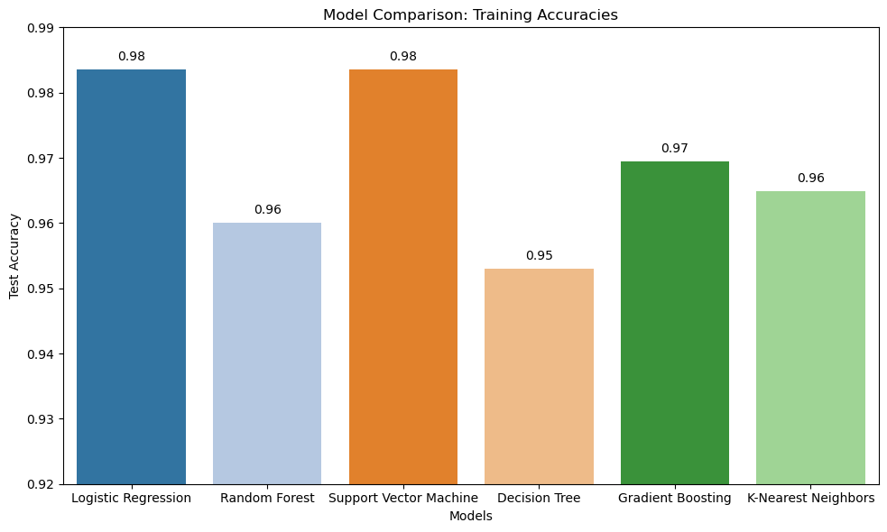

```python
plt.figure(figsize=(10, 6))

ax = sns.barplot(classifiers_names, training_accuracy_GridSearch, palette='tab20')
plt.title('Model Comparison: Training Accuracies')
plt.xlabel('Models')
plt.ylabel('Test Accuracy')

for p in ax.patches:
    ax.annotate(format(p.get_height(), '.2f'),
                (p.get_x() + p.get_width() / 2., p.get_height()),
                ha = 'center', va = 'center',
                xytext = (0, 10),
                textcoords = 'offset points')

plt.ylim(0.92, 0.99)
plt.tight_layout()

plt.show()
```

#### In this code:

- A bar plot is created to visualize the training accuracies of different models after performing Grid Search.
- The figure size is set using plt.figure(figsize=(10, 6)).
- A Barplot is created with model names on the x-axis and training accuracies on the y-axis.
- This chart helps compare the training accuracies of different models after hyperparameter tuning.

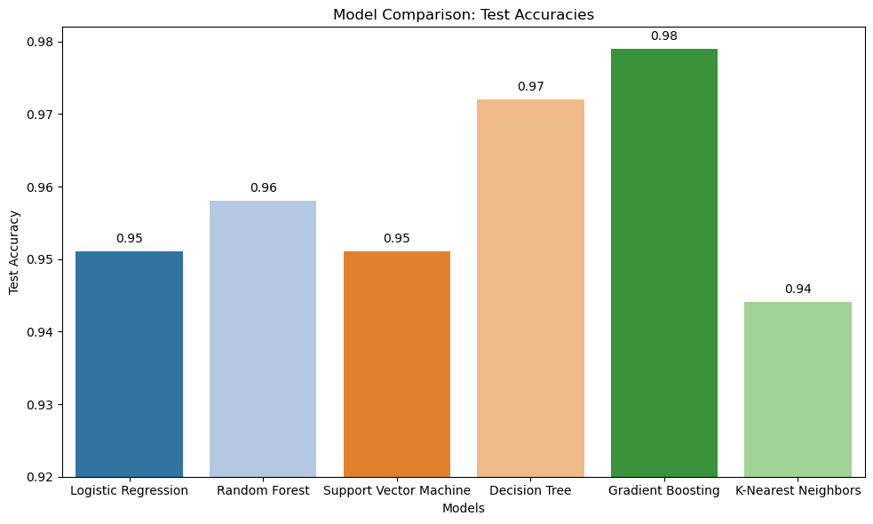

```python
plt.figure(figsize=(10, 6))

ax = sns.barplot(classifiers_names, testing_accuracy_GridSearch, palette='tab20')
plt.title('Model Comparison: Test Accuracies')
plt.xlabel('Models')
plt.ylabel('Test Accuracy')

for p in ax.patches:
    ax.annotate(format(p.get_height(), '.2f'),
                (p.get_x() + p.get_width() / 2., p.get_height()),
                ha = 'center', va = 'center',
                xytext = (0, 10),
                textcoords = 'offset points')

plt.ylim(0.92, 0.982)
plt.tight_layout()

plt.show()
```

#### In this code:

- A bar plot is created to visualize the testing accuracies of different models after performing Grid Search.
- The figure size is set using `plt.figure(figsize=(10, 6))`.
- A Barplot is created with model names on the x-axis and testing accuracies on the y-axis.
- This chart helps compare the testing accuracies of different models after hyperparameter tuning.

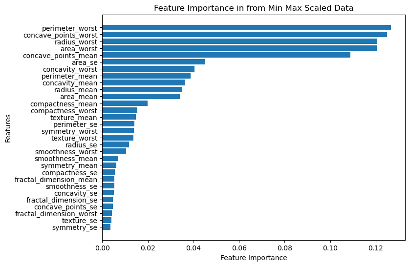

```python
rand_forest = RandomForestClassifier(max_depth=None, n_estimators= 100, random_state=456)

rand_forest.fit(min_max_xtrain, ytrain)

min_max_feature_importance = rand_forest.feature_importances_
min_max_feature_importance_df = pd.DataFrame({'Feature': x.columns, 'Importance': min_max_feature_importance})
min_max_feature_importance_df = min_max_feature_importance_df.sort_values(by='Importance', ascending=False)

# Plot feature importance
plt.figure(figsize=(8, 6))
plt.barh(min_max_feature_importance_df['Feature'], min_max_feature_importance_df['Importance'])
plt.xlabel('Feature Importance')
plt.ylabel('Features')
plt.title('Feature Importance in from Min Max Scaled Data')
plt.gca().invert_yaxis()  # Invert y-axis to show the most important features at the top
plt.show()
```

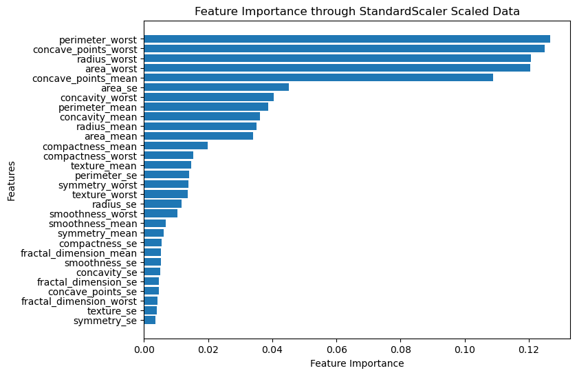

```python
rand_forest = RandomForestClassifier(max_depth=None, n_estimators= 100, random_state=456)

rand_forest.fit(standard_xtrain, ytrain)

standard_feature_importance = rand_forest.feature_importances_
standard_feature_importance_df = pd.DataFrame({'Feature': x.columns, 'Importance': standard_feature_importance})
standard_feature_importance_df = standard_feature_importance_df.sort_values(by='Importance', ascending=False)

# Plot feature importance
plt.figure(figsize=(8, 6))
plt.barh(standard_feature_importance_df['Feature'], standard_feature_importance_df['Importance'])
plt.xlabel('Feature Importance')
plt.ylabel('Features')
plt.title('Feature Importance through StandardScaler Scaled Data')
plt.gca().invert_yaxis()  # Invert y-axis to show the most important features at the top
plt.show()
```

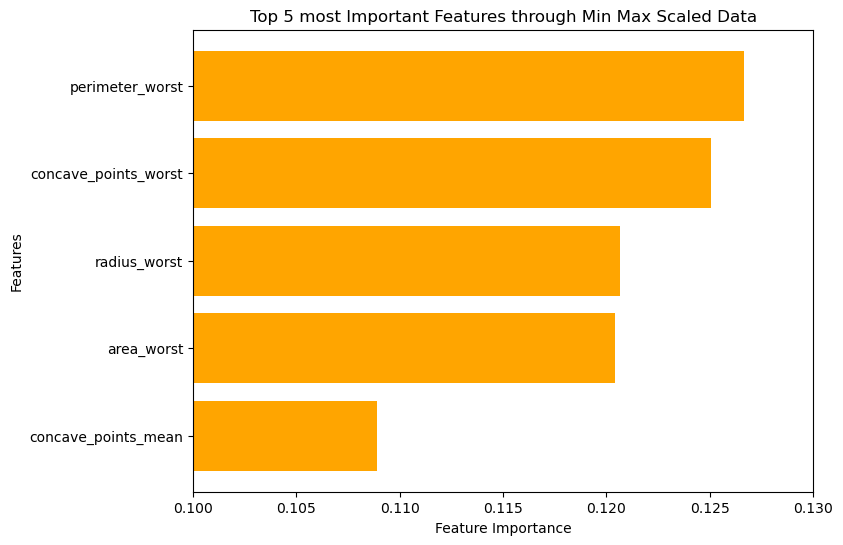

```python
# Plot feature importance
plt.figure(figsize=(8, 6))
plt.barh(min_max_feature_importance_df['Feature'][:5], min_max_feature_importance_df['Importance'][:5], color='orange')
plt.xlabel('Feature Importance')
plt.ylabel('Features')
plt.title('Top 5 most Important Features through Min Max Scaled Data')
plt.gca().invert_yaxis()
plt.xlim(0.1, 0.13)
plt.show()
```

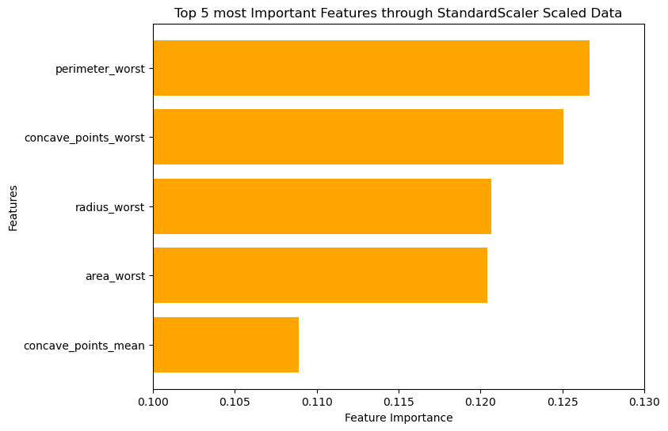

```python
# Plot feature importance

plt.figure(figsize=(8, 6))
plt.barh(standard_feature_importance_df['Feature'][:5], standard_feature_importance_df['Importance'][:5], color='orange')
plt.xlabel('Feature Importance')
plt.ylabel('Features')
plt.title('Top 5 most Important Features through StandardScaler Scaled Data')
plt.gca().invert_yaxis()
plt.xlim(0.1, 0.13)
plt.show()
```

# Comparative Analysis Report

### Dataset Description:

The dataset used for this analysis contains a set of features used to predict a binary target variable (`diagnosis`), making it a classification problem.

### Data Preprocessing:

The dataset underwent preprocessing, including encoding categorical variables (mapping `'B'` to `0` and `'M'` to `1`) and scaling features using both `MinMaxScaler` and `StandardScaler`. The data was split into training and testing sets.

### Evaluation Metrics:

Four evaluation metrics were used to assess classifier performance: Accuracy, Precision, Recall, and F1-Score. These metrics provide a comprehensive view of classifier performance.

### Hyperparameter Tuning with GridSearchCV:

`GridSearchCV` was applied to tune the hyperparameters of the six classifiers: `Logistic Regression`, `Random Forest`, `Support Vector Machine (SVM)`, `Decision Tree`, `Gradient Boosting`, and `K-Nearest Neighbors (KNN)`. The goal was to find the best combination of hyperparameters that would result in improved `training and testing accuracies`.

### Results After Hyperparameter Tuning:

#### Training Accuracies:

1. Logistic Regression:

   Achieved an impressive training accuracy of `0.983` after hyperparameter tuning.
1. Random Forest:

   Achieved a `training accuracy` of `0.98`, matching `Logistic Regression` as the highest.

#### Testing Accuracies:

1. Decision Tree:

   Achieved a `testing accuracy` of `0.972` after hyperparameter tuning.
1. Gradient Boosting:

### Feature Importance:

The most important features for both the StandardScaler as well as the MinMaxScaler are `perimeter_worst`, `concave_points_worst`, `radius_worst`, `area_worst`, and `concave_points_mean`. These are those distinctive features which really affects the classification of a cell being `Benign` or `Malignant`.